# Statystyczna Analiza Danych

Ćwiczenia 1

6 października 2017

### Zadanie 1

Uczymy się rzucać kością… i co wychodzi?

```r
throw <- sample(1:6, 600, replace = TRUE)
head(throw)
```

```
## [1] 5 1 2 5 4 6
```

Funkcja `head` pozwala obejrzeć początkowe wyrazy wektora/wiersze tablicy (domyślnie 6 pierwszych). Jak na razie wiele nam to nie mówi; wygodniej spojrzeć na ‘stablicowane’ wartości:

```r
table(throw)
```

```
## throw
##   1   2   3   4   5   6
## 103  94  98  98  93 114
```

Wygląda sensownie. A co, gdybyśmy mieli `replace=FALSE`? Będzie krzyczeć!

To teraz bierzemy się za histogram.

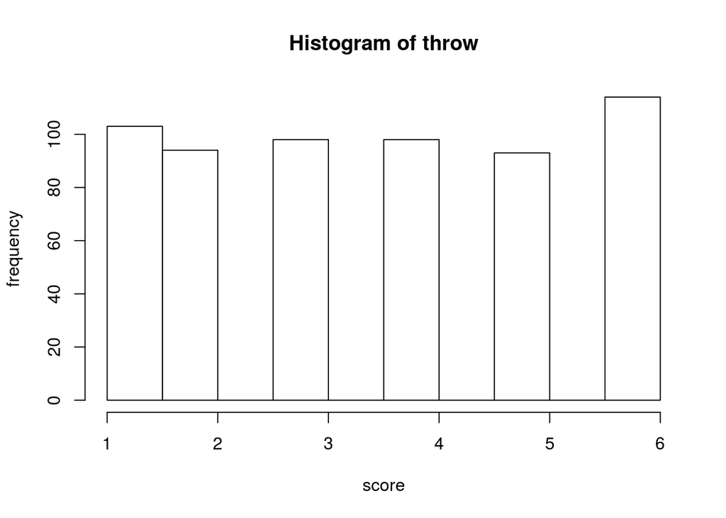

```r
hist(throw, xlab = "score", ylab = "frequency")
```

No nie wygląda to specjalnie zachęcająco. Zgodnie z radą dra Nobla, próbujemy wykonać `barplot`

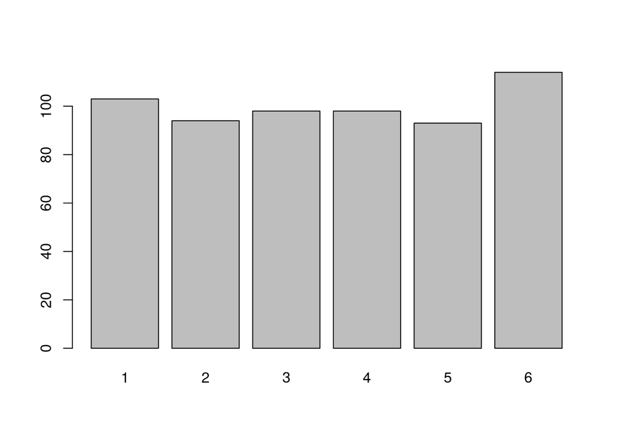

```r
barplot(table(throw) )
```

I od razu przyjemniej się na to patrzy! A jakie są estymowane parametry tego rozkładu?

```r
mean(throw)
```

```
## [1] 3.543333
```

```r
sd(throw)
```

```
## [1] 1.745432
```

Przypomnijmy sobie zatem, ile wynoszą wartości teoretyczne! **TABLICA**